# Midterm 2

## Question 1

### Tim Demetriades

11/20/2021

#### Solve the following using steepest descent algorithm. Start with 𝑥0 = [1 1 1]𝑇 and use stopping threshold ∈ = 10^−6.

```python
import numpy as np
import matplotlib.pyplot as plt
```

```python
x = np.ones((3)).T
stopping_threshold = 10**-6
iterations = 1000

objective_f_list = []
```

```python
def calculate_objective_f():
    objective_f = (x[0] + 5)**2 + (x[1] + 8)**2 + (x[2] + 7)**2 + (2*x[0]**2)*(x[1]**2) + (4*x[0]**2)*(x[2]**2)
    return objective_f
```

```python
def calculate_gradient():
    gradient = np.array([[2*x[0] + 10 + 4*x[0]*(x[1]**2) + 8*x[0]*(x[2]**2)],
                         [2*x[1] + 16 + (4*x[0]**2)*x[1]],
                         [2*x[2] + 14 + (8*x[0]**2)*x[2]]])
    return gradient
```

```python
def calculate_hessian():
    hessian = np.array([[(2 + 4*x[1]**2 + 8*x[2]**2), (8*x[0]*x[1]),   (16*x[0]*x[2])],
                        [(8*x[0]*x[1]),               (2 + 4*x[0]**2), (0)           ],
                        [(16*x[0]*x[2]),              (0),             (2 + 16*x[0])]])
    return hessian
```

```python
def steepest_descent(iterations):
    k = 1
    for iter in range(iterations):
        objective_f = calculate_objective_f()

        gradient = calculate_gradient()
        hessian = calculate_hessian()

        alpha = (gradient.T @ gradient) / (gradient.T @ hessian @ gradient)

        for i in range(len(x)):
            x[i] = x[i] - alpha * gradient[i]

        norm = np.linalg.norm(alpha * gradient)

        objective_f_list.append(objective_f)

        if (norm < stopping_threshold):
            objective_f = calculate_objective_f()
            objective_f_list.append(objective_f)
            return k, objective_f, gradient, hessian
        else:
            k += 1
```

```python
k, objective_f, gradient, hessian = steepest_descent(iterations)
```

```python
print(f'Number of iterations needed to reach stopping threshold: {k}')
print(f'Minimizer of Objective Function = [{x[0]:.3f} {x[1]:.3f} {x[2]:.3f}]')
print(f'Minimum of Objective Function = {objective_f:.3f}')
```

```
Number of iterations needed to reach stopping threshold: 964
Minimizer of Objective Function = [-0.015 -7.996 -6.993]
Minimum of Objective Function = 24.923
```

Above we can see that at around [0 -8 -7] we achieve a minumum value of approximately 25.

#### (a) Verify that the final solution satisfies the second order necessary conditions for a minimum.

```python
print('Gradient = ')
print(gradient)
print('\n')
print('Hessian = ')
print(hessian)
```

```
Gradient =
[[0.00053272]
 [0.00014258]
 [0.00014154]]


Hessian =
[[649.00121982   0.98560139   1.72398225]
 [  0.98560139   2.00094956   0.        ]
 [  1.72398225   0.           1.75348047]]
```

```python
determinant1 = np.linalg.det(hessian)              # determinant of the upper left 4 values in the hessian
determinant2 = np.linalg.det(hessian[0:2, 0:2])    # determinant of entire hessian matrix
print(f'Determinant 1 of Hessian = {determinant1}')
print(f'Determinant 2 of Hessian = {determinant2}')
```

```
Determinant 1 of Hessian = 2269.4521363645467
Determinant 2 of Hessian = 1297.6472955253037
```

- **The gradient = 0**
- **The hessian is positive definite**

As we can see, after the algorithm finishes the value of the gradient may not quite be 0 but it is very close.

#### (b) Plot the value of the objective function with respect to the number of iterations

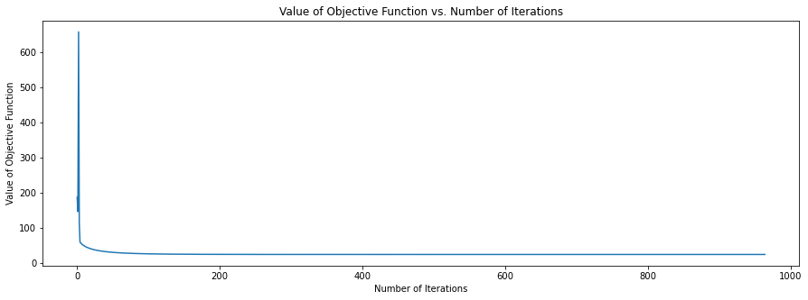

```python
plt.figure(figsize = (15, 5))
plt.title('Value of Objective Function vs. Number of Iterations')
plt.xlabel('Number of Iterations')
plt.ylabel('Value of Objective Function')
plt.plot(objective_f_list)
plt.show()
```

#### (c) Comment on the convergence speed of the algorithm.

The steepest descent algorithm has a **linear rate of convergence**. However, even with slightly non-linear problems like this problem, the rate of convergence can be slow compared to other methods.

If a function has a local minimizer and its hessian is positive definite (our function satisfies both of these conditions) then for values of x sufficiently close to the minimizer we have:

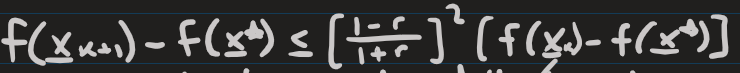

In the above formula, r is equivalent to the smallest eigenvalue of the hessian divided by the largest eigenvalue of the hessian. It is essentially the upper bounds and controls the rate of convergence. Below is the formula for the convergence ratio, beta.

With steepest descent, the rate of convergence is high if eigenvalues of the hessian are all nearly equal, and low if at least one eigenvalue is small relative to the largest eigenvalue.

```python
eigenvalues, eigenvectors = np.linalg.eig(hessian)
```

```python
eigenvalues
```

```
array([649.00731309,   1.74886107,   1.99947568])
```

```python
r = eigenvalues[1] / eigenvalues[0]
beta = ((1 - r) / (1 + r)) ** 2
print(f"r = {r:.3f}")
print(f"Convergence Ratio = {beta:.3f}")
```

```
r = 0.003
Convergence Ratio = 0.989
```

As seen above, the largest eigenvalue of the hessian is much larger than the other two. We also calculate the value of r and the convergence ratio, beta, shown above. The convergence ratio is very close to 1 as a result of the value of r being very low. **This means that the rate of convergence is rather slow.**